# SCAN-B processing: Hallmark ssGSEA and inputs for the breast figure scripts

Pan-cancer aging project

October 24, 2026

## Libraries

```r
suppressPackageStartupMessages({
  library(dplyr)
  library(tibble)
  library(tidyr)
  library(purrr)
  library(stringr)
  library(ggplot2)
  library(grid)            # unit()
  library(scales)

  library(SummarizedExperiment)
  library(edgeR)
  library(msigdbr)
  library(GSVA)

  library(glmnet)

  library(AnnotationDbi)
  library(org.Hs.eg.db)

  library(ClockSHAP)
  library(ComplexHeatmap)
  library(circlize)

  library(survival)
  library(broom)
})
```

## Global paths + helpers

```r
analysis_id <- paste0(params$tcga_project, "__", params$gtex_project)
suffix      <- paste0("-", params$feature_set)
proc_dir    <- file.path(params$out_root, analysis_id)

clock_rds      <- file.path(proc_dir, paste0("clock_and_RAA_objects", suffix, ".rds"))
metadata_rds   <- file.path(proc_dir, "sample_metadata.rds")
scores_gtex_rds <- file.path(proc_dir, paste0("ssgsea_scores_gtex", suffix, ".rds"))
scores_nt_rds   <- file.path(proc_dir, paste0("ssgsea_scores_nt",   suffix, ".rds"))
scores_pt_rds   <- file.path(proc_dir, paste0("ssgsea_scores_pt",   suffix, ".rds"))
clockshap_rds   <- file.path(proc_dir, paste0("clockshap_objects",  suffix, ".rds"))

FIG_DIR <- params$fig_dir

stopifnot(file.exists(clock_rds), file.exists(metadata_rds), file.exists(scores_gtex_rds))
```

## Load official BRCA (GTEx-trained) clock objects (clock and ClockSHAP steps)

```r
clock_results <- readRDS(clock_rds)
metadata      <- readRDS(metadata_rds)
scores_gtex   <- readRDS(scores_gtex_rds)

scores_nt <- if (file.exists(scores_nt_rds)) readRDS(scores_nt_rds) else NULL
scores_pt <- if (file.exists(scores_pt_rds)) readRDS(scores_pt_rds) else NULL

# Prefer the saved ClockSHAP bundle if available (contains clock + reference)
clockshap_bundle <- if (file.exists(clockshap_rds)) readRDS(clockshap_rds) else NULL

feat <- clock_results$feature_names
stopifnot(all(feat %in% rownames(scores_gtex)))
```

## Fit GTEx reference line (for anchoring + residuals)

```r
pred_gtex <- clock_results$pred$GTEx
age_gtex  <- clock_results$age$GTEx[names(pred_gtex)]

ok_g <- complete.cases(pred_gtex, age_gtex)
pred_gtex <- pred_gtex[ok_g]
age_gtex  <- age_gtex[ok_g]

bias_fit <- lm(pred_gtex ~ age_gtex)
beta0 <- coef(bias_fit)[1]
beta1 <- coef(bias_fit)[2]

c(beta0 = beta0, beta1 = beta1, n_gtex = length(pred_gtex))
```

```
## beta0.(Intercept)    beta1.age_gtex            n_gtex
##        42.6275560         0.1781736       482.0000000
```

## SCAN-B processing (counts → logCPM → Hallmark ssGSEA)

This block processes SCAN-B from the raw SummarizedExperiment, kept minimal and scoped to what the clock and ClockSHAP need.

```r
# 0) Hallmark gene sets (same naming convention as pipeline steps)
.hallmark_sets <- local({
  nice <- function(x) x |>
    stringr::str_remove("^HALLMARK_") |>
    stringr::str_replace_all("_", " ") |>
    stringr::str_to_title()
  hall_raw <- msigdbr::msigdbr(species = "Homo sapiens", category = "H")
  split(hall_raw$gene_symbol, nice(hall_raw$gs_name))
})

.to_logcpm <- function(se, assay_name = "counts") {
  stopifnot(assay_name %in% SummarizedExperiment::assayNames(se))
  edgeR::cpm(SummarizedExperiment::assay(se, assay_name), log = TRUE, prior.count = 1)
}

.ensembl_to_symbol <- function(ensembl_ids) {
  bare <- sub("\\.\\d+$", "", ensembl_ids)
  syms <- AnnotationDbi::mapIds(
    org.Hs.eg.db,
    keys = bare,
    keytype = "ENSEMBL",
    column = "SYMBOL",
    multiVals = "first"
  )
  names(syms) <- ensembl_ids
  syms
}

.collapse_to_symbols <- function(logcpm, symbols) {
  keep <- !is.na(symbols) & symbols != ""
  logcpm  <- logcpm[keep, , drop = FALSE]
  symbols <- symbols[keep]
  summed  <- rowsum(logcpm, group = symbols)
  counts  <- table(symbols)[rownames(summed)]
  sweep(summed, 1, as.numeric(counts), "/")
}

.run_ssgsea <- function(expr_sym_gxs, hallmark_sets = .hallmark_sets) {
  param <- GSVA::ssgseaParam(
    exprData  = expr_sym_gxs,
    geneSets  = hallmark_sets,
    minSize   = 1,
    maxSize   = Inf,
    alpha     = 0.25,
    normalize = FALSE
  )
  GSVA::gsva(param, verbose = FALSE)
}

process_scanb_for_clock <- function(se,
                                    assay_name = "counts",
                                    id_type = c("ensembl", "symbol")) {
  id_type <- match.arg(id_type)

  logcpm <- .to_logcpm(se, assay_name)

  if (id_type == "ensembl") {
    syms <- .ensembl_to_symbol(rownames(logcpm))
    logcpm_sym <- .collapse_to_symbols(logcpm, syms)
  } else {
    logcpm_sym <- .collapse_to_symbols(logcpm, rownames(logcpm))
  }

  ssgsea_pxs <- .run_ssgsea(logcpm_sym)

  list(
    logcpm_sym = logcpm_sym,
    ssgsea_pxs = ssgsea_pxs
  )
}
```

### Load + filter SCAN-B SE (best replicate per sample; invasive tumors)

```r
stopifnot(file.exists(params$scanb_se_rds))
scanb <- readRDS(params$scanb_se_rds)

cd <- as.data.frame(SummarizedExperiment::colData(scanb))
cd$run_id <- rownames(cd)

# Best replicate: highest ALIGNED_PAIRS per Sample
best_replicates <- cd |>
  dplyr::group_by(Sample) |>
  dplyr::slice_max(order_by = ALIGNED_PAIRS, n = 1, with_ties = FALSE) |>
  dplyr::ungroup()

scanb_best <- scanb[, best_replicates$run_id]

# Filter to match TCGA BRCA: invasive primary tumors only
cd2 <- as.data.frame(SummarizedExperiment::colData(scanb_best))

is_normal <- cd2$SpecimenType %in% "Normal"
is_ln     <- cd2$SpecimenType %in% "LN"
is_dcis   <- cd2$OpBiopsy.InvCa %in% "In situ only"
drop <- is_normal | is_ln | is_dcis
drop[is.na(drop)] <- FALSE

scanb_tumor <- scanb_best[, !drop]

# Add age_years (SCAN-B has 5-year binned age)
age_col <- "Age..5.year.range..e.g...35.31.35...40.36.40...45.41.45..etc.."
stopifnot(age_col %in% colnames(SummarizedExperiment::colData(scanb_tumor)))
SummarizedExperiment::colData(scanb_tumor)$age_years <- as.numeric(
  SummarizedExperiment::colData(scanb_tumor)[[age_col]]
)

summary(SummarizedExperiment::colData(scanb_tumor)$age_years)
```

```
##    Min. 1st Qu.  Median    Mean 3rd Qu.    Max.    NA's
##   25.00   55.00   65.00   64.74   75.00  100.00     421
```

### Compute Hallmark ssGSEA for SCAN-B

```r
scanb_proc <- process_scanb_for_clock(
  se = scanb_tumor,
  assay_name = params$scanb_counts_assay,
  id_type = "ensembl"
)

scanb_scores_pxs <- scanb_proc$ssgsea_pxs
stopifnot(all(feat %in% rownames(scanb_scores_pxs)))
```

## Apply BRCA clock to SCAN-B (raw predictions + GTEx-anchored residuals)

```r
X_scanb <- t(scanb_scores_pxs[feat, , drop = FALSE])
scanb_ids <- rownames(X_scanb)

scanb_age <- as.numeric(SummarizedExperiment::colData(scanb_tumor)[scanb_ids, "age_years"])
names(scanb_age) <- scanb_ids

pred_scanb_raw <- as.numeric(predict(
  clock_results$enet_model,
  newx = X_scanb,
  s = clock_results$tuning$best_lambda
))
names(pred_scanb_raw) <- scanb_ids

scanb_pred_df <- tibble::tibble(
  sample_id = scanb_ids,
  age_years = scanb_age[scanb_ids],
  predicted = pred_scanb_raw[scanb_ids]
) %>%
  dplyr::filter(is.finite(age_years), is.finite(predicted)) %>%
  dplyr::mutate(
    # Anchored prediction (GTEx-anchored)
    pred_anchored = predicted - beta0 + (1 - beta1) * age_years,
    # GTEx-anchored residual / deviation
    dev_gtex = predicted - (beta0 + beta1 * age_years)
  )

scanb_pred_df %>% dplyr::slice_head(n = 5)
```

```
## # A tibble: 5 × 5
##   sample_id                     age_years predicted pred_anchored dev_gtex
##   <chr>                             <dbl>     <dbl>         <dbl>    <dbl>
## 1 S000001.l.r.m.c.lib.g.k2.a.t         85      34.3          61.6    -23.4
## 2 S000002.l.r.m.c.lib.g.k2.a.t         70      26.3          41.2    -28.8
## 3 S000003.l.r.m2.c.lib.g.k2.a.t        65      25.6          36.4    -28.6
## 4 S000004.l.r.m.c.lib.g.k2.a.t         30      35.9          18.0    -12.0
## 5 S000005.l.r.m.c.lib.g.k2.a.t         70      41.5          56.4    -13.6
```

## ClockSHAP for SCAN-B (GTEx reference)

```r
# Prefer using the saved ClockSHAP bundle (ensures identical reference + clock parameterization)
if (!is.null(clockshap_bundle)) {
  clock_cs <- clockshap_bundle$clock
  reference <- clockshap_bundle$reference
} else {
  # Fallback: build ClockSHAP objects from Step-02 saved parameters + GTEx features
  cs <- clock_results$clock_cs
  if (is.null(names(cs$beta)))  names(cs$beta)  <- feat
  if (is.null(names(cs$mu)))    names(cs$mu)    <- feat
  if (is.null(names(cs$sigma))) names(cs$sigma) <- feat

  clock_cs <- ClockSHAP::linear_clock(
    alpha = cs$alpha,
    beta  = cs$beta[feat],
    mu    = cs$mu[feat],
    sigma = cs$sigma[feat]
  )

  X_gtex <- t(scores_gtex[feat, , drop = FALSE])
  age_g <- as.numeric(metadata[rownames(X_gtex), "age_years"])
  keep_g <- is.finite(age_g)

  reference <- ClockSHAP::fit_reference_profile(
    features = as.data.frame(X_gtex[keep_g, , drop = FALSE]),
    age      = age_g[keep_g]
  )
}

# ClockSHAP requires complete age
ok_scanb <- is.finite(scanb_pred_df$age_years) & scanb_pred_df$age_years > 0
X_scanb_cs <- X_scanb[scanb_pred_df$sample_id[ok_scanb], , drop = FALSE]
age_scanb_cs <- scanb_pred_df$age_years[ok_scanb]

cs_scanb <- ClockSHAP::clockshap(
  features  = X_scanb_cs,
  age       = age_scanb_cs,
  clock     = clock_cs,
  reference = reference
)

# Invariant check
max_abs_err <- max(abs(rowSums(cs_scanb$phi) - cs_scanb$deviation), na.rm = TRUE)
max_abs_err
```

```
## [1] 2.131628e-14
```

## Proof block (optional): GTEx-anchored residual equals ClockSHAP deviation

```r
sid <- rownames(cs_scanb$phi)

pred_cs <- cs_scanb$predicted; names(pred_cs) <- sid
exp_cs  <- cs_scanb$expected;  names(exp_cs)  <- sid
age_cs  <- cs_scanb$age;       names(age_cs)  <- sid

proof_df <- tibble::tibble(
  sample_id = sid,
  age       = as.numeric(age_cs[sid]),
  predicted = as.numeric(pred_cs[sid]),
  expected  = as.numeric(exp_cs[sid]),
  dev_shap  = as.numeric(pred_cs[sid] - exp_cs[sid])
) %>%
  dplyr::filter(complete.cases(age, predicted, expected, dev_shap)) %>%
  dplyr::mutate(dev_gtex_resid = predicted - (beta0 + beta1 * age))

c(
  cor_dev_shap_vs_gtex_resid = cor(proof_df$dev_shap, proof_df$dev_gtex_resid),
  max_abs_diff = max(abs(proof_df$dev_shap - proof_df$dev_gtex_resid), na.rm = TRUE)
)
```

```
## cor_dev_shap_vs_gtex_resid               max_abs_diff
##               1.000000e+00               4.263256e-14
```

# Exploratory panels (not used in the manuscript)

## Platform diagnostic — PCA in Hallmark ssGSEA space

Cross-cohort PCA on Hallmark ssGSEA scores for GTEx, TCGA-BRCA NAT, TCGA-BRCA PT, and SCAN-B. Shows where SCAN-B sits relative to the training reference (GTEx) and to TCGA-BRCA in pathway-score space. NAT and PT are included if their saved score files are present; the PCA proceeds with whatever cohorts are available.

```r
mat_list <- list(
  "GTEx"     = scores_gtex,
  "TCGA-NAT" = scores_nt,
  "TCGA-PT"  = scores_pt,
  "SCAN-B"   = scanb_scores_pxs
)
mat_list <- mat_list[!vapply(mat_list, is.null, logical(1))]

# Restrict to the Hallmark set shared across all included cohorts
pathways_common <- Reduce(intersect, lapply(mat_list, rownames))
stopifnot(length(pathways_common) > 0)

combined_mat <- do.call(
  cbind,
  lapply(mat_list, function(m) m[pathways_common, , drop = FALSE])
)
cohort_vec <- rep(names(mat_list), vapply(mat_list, ncol, integer(1)))

pca_fit <- stats::prcomp(t(combined_mat), center = TRUE, scale. = TRUE)
ve <- round(100 * pca_fit$sdev^2 / sum(pca_fit$sdev^2), 1)

cohort_levels_pca <- intersect(
  c("GTEx", "TCGA-NAT", "TCGA-PT", "SCAN-B"),
  unique(cohort_vec)
)

pc_df <- as.data.frame(pca_fit$x[, 1:2]) %>%
  dplyr::mutate(cohort = factor(cohort_vec, levels = cohort_levels_pca))

# Sample counts per cohort included in the PCA
pca_n_tbl <- pc_df %>% dplyr::count(cohort, name = "n_samples")
knitr::kable(pca_n_tbl, caption = "Hallmark PCA: samples per cohort.")
```

Hallmark PCA: samples per cohort.

| cohort | n_samples |
| --- | --- |
| GTEx | 482 |
| TCGA-NAT | 112 |
| TCGA-PT | 1127 |
| SCAN-B | 8165 |

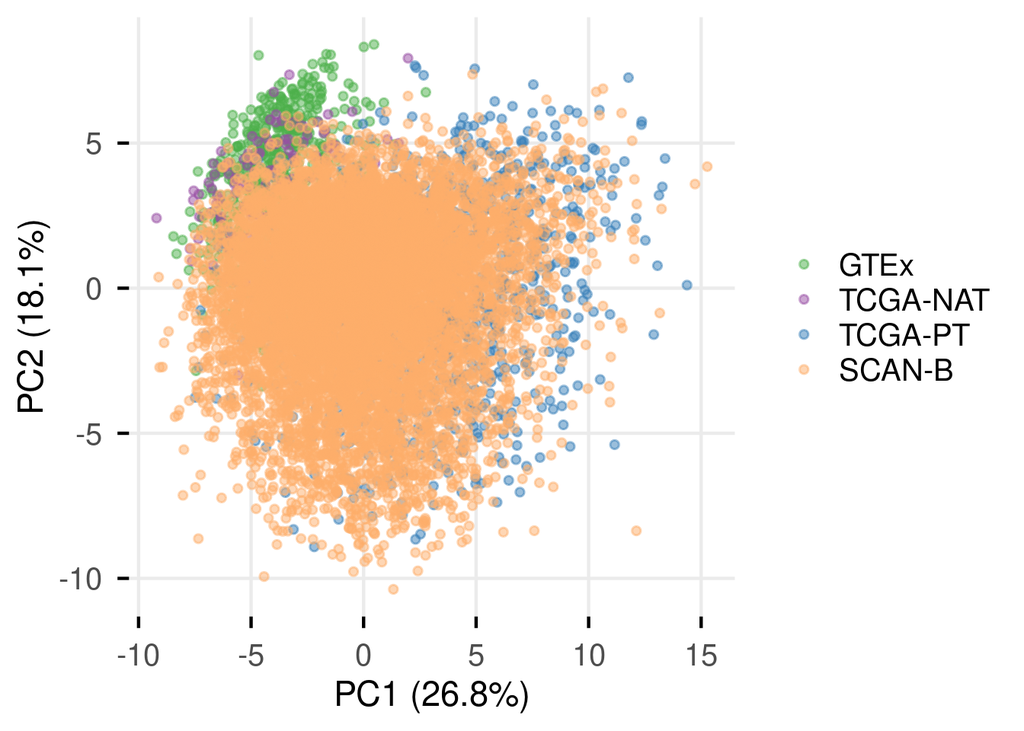

```r
cohort_cols_pca <- c(
  "GTEx"     = "#4daf4a",
  "TCGA-NAT" = "#984ea3",
  "TCGA-PT"  = "#377eb8",
  "SCAN-B"   = "#fdae6b"
)

p_supp_pca <- ggplot2::ggplot(
  pc_df,
  ggplot2::aes(x = PC1, y = PC2, colour = cohort)
) +
  ggplot2::geom_point(alpha = 0.5, size = 1.5) +
  ggplot2::scale_colour_manual(values = cohort_cols_pca) +
  ggplot2::labs(
    x = paste0("PC1 (", ve[1], "%)"),
    y = paste0("PC2 (", ve[2], "%)")
  ) +
  ggplot2::theme_minimal(base_size = 17) +
  ggplot2::theme(
    legend.title      = ggplot2::element_blank(),
    panel.grid.minor  = ggplot2::element_blank(),
    axis.ticks        = ggplot2::element_line(),
    axis.ticks.length = grid::unit(2, "mm"),
    axis.title        = ggplot2::element_text(size = 17),
    axis.text         = ggplot2::element_text(size = 15),
    legend.text       = ggplot2::element_text(size = 15)
  )

p_supp_pca
```

```r
if (isTRUE(params$save_figures)) {
  out_dir <- FIG_DIR
  dir.create(out_dir, recursive = TRUE, showWarnings = FALSE)

  ggsave(
    filename = file.path(out_dir, "supplementary_scanb_hallmark_pca.pdf"),
    plot   = p_supp_pca,
    width  = 210 / 25.4,
    height = 150 / 25.4,
    units  = "in"
  )

  message("Saved: ", file.path(out_dir, "supplementary_scanb_hallmark_pca.pdf"))
} else {
  message("save_figures=FALSE; skipping save: supplementary_scanb_hallmark_pca.pdf")
}
```

## Anchored predicted age vs chronological age (GTEx vs SCAN-B)

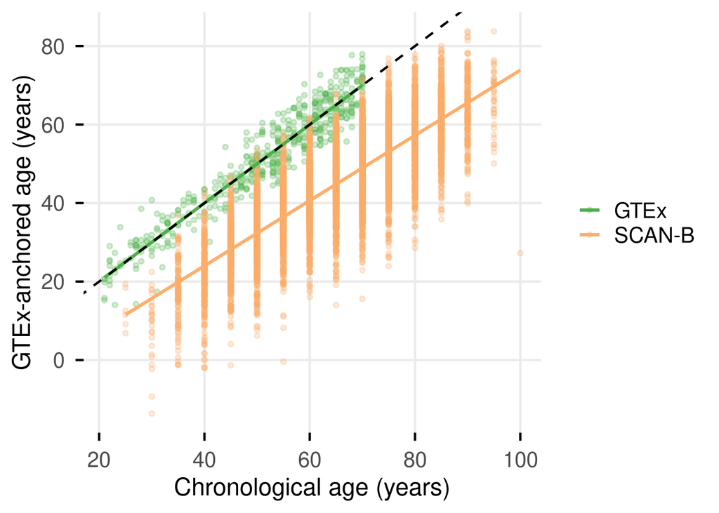

```r
## -------------------------------------------------------------
## Age vs GTEx-anchored predicted age
##   Anchoring uses GTEx-only fit: pred ~ age
## -------------------------------------------------------------

# GTEx plotting df
gtex_df <- tibble::tibble(
  cohort = "GTEx",
  age_years = as.numeric(age_gtex),
  pred_anchored = as.numeric(pred_gtex - beta0 + (1 - beta1) * age_gtex)
) %>%
  dplyr::filter(complete.cases(age_years, pred_anchored))

# SCAN-B plotting df
scanb_df <- scanb_pred_df %>%
  dplyr::transmute(
    cohort = "SCAN-B",
    age_years,
    pred_anchored
  )

plot_df <- dplyr::bind_rows(gtex_df, scanb_df) %>%
  dplyr::mutate(cohort = factor(cohort, levels = c("GTEx", "SCAN-B")))

cols <- c("GTEx" = "#4daf4a", "SCAN-B" = "#fdae6b")

p_supp3A <- ggplot(plot_df, aes(x = age_years, y = pred_anchored, colour = cohort)) +
  geom_point(alpha = 0.25, size = 1.2) +
  geom_smooth(method = "lm", se = FALSE, linewidth = 1.1) +
  geom_abline(slope = 1, intercept = 0, linetype = "dashed", colour = "black") +
  scale_colour_manual(values = cols) +
  labs(
    x = "Chronological age (years)",
    y = "GTEx-anchored age (years)"
  ) +
  theme_minimal(base_size = 17) +
  theme(
    legend.title      = element_blank(),
    panel.grid.minor  = element_blank(),
    axis.ticks        = element_line(),
    axis.ticks.length = unit(2, "mm"),
    axis.title        = element_text(size = 17),
    axis.text         = element_text(size = 15),
    legend.text       = element_text(size = 15)
  )

p_supp3A
```

```r
if (isTRUE(params$save_figures)) {
  out_dir <- FIG_DIR
  dir.create(out_dir, recursive = TRUE, showWarnings = FALSE)

  ggsave(
    filename = file.path(out_dir, "supplementary_scanb_age_vs_anchored_pred.pdf"),
    plot   = p_supp3A,
    width  = 210 / 25.4,
    height = 120 / 25.4,
    units  = "in"
  )

  message("Saved: ", file.path(out_dir, "supplementary_scanb_age_vs_anchored_pred.pdf"))
} else {
  message("save_figures=FALSE; skipping save: supplementary_scanb_age_vs_anchored_pred.pdf")
}
```

## Supplementary anchored-age comparison including TCGA-BRCA

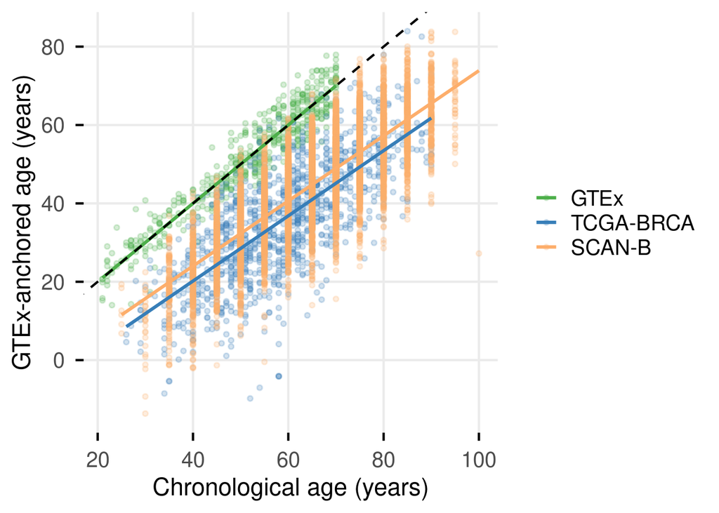

```r
## -------------------------------------------------------------
## Supplementary anchored-age comparison: GTEx vs TCGA-BRCA vs SCAN-B
##   Uses the GTEx-only anchoring fit from the official BRCA clock
## -------------------------------------------------------------

brca_df <- tibble::tibble(
  cohort = "TCGA-BRCA",
  age_years = as.numeric(clock_results$age$Tumour),
  pred_anchored = as.numeric(clock_results$pred$Tumour - beta0 + (1 - beta1) * clock_results$age$Tumour)
) %>%
  dplyr::filter(complete.cases(age_years, pred_anchored))

plot_df_with_brca <- dplyr::bind_rows(gtex_df, brca_df, scanb_df) %>%
  dplyr::mutate(cohort = factor(cohort, levels = c("GTEx", "TCGA-BRCA", "SCAN-B")))

cols_with_brca <- c(
  "GTEx" = "#4daf4a",
  "TCGA-BRCA" = "#377eb8",
  "SCAN-B" = "#fdae6b"
)

p_supplementary_anchored_age_with_brca <- ggplot(
  plot_df_with_brca,
  aes(x = age_years, y = pred_anchored, colour = cohort)
) +
  geom_point(alpha = 0.22, size = 1.2) +
  geom_smooth(method = "lm", se = FALSE, linewidth = 1.1) +
  geom_abline(slope = 1, intercept = 0, linetype = "dashed", colour = "black") +
  scale_colour_manual(values = cols_with_brca) +
  labs(
    x = "Chronological age (years)",
    y = "GTEx-anchored age (years)"
  ) +
  theme_minimal(base_size = 17) +
  theme(
    legend.title      = element_blank(),
    panel.grid.minor  = element_blank(),
    axis.ticks        = element_line(),
    axis.ticks.length = unit(2, "mm"),
    axis.title        = element_text(size = 17),
    axis.text         = element_text(size = 15),
    legend.text       = element_text(size = 15)
  )

p_supplementary_anchored_age_with_brca
```

```r
out_dir <- FIG_DIR
dir.create(out_dir, recursive = TRUE, showWarnings = FALSE)

ggsave(
  filename = file.path(out_dir, "supplementary_anchored_age_with_brca.pdf"),
  plot   = p_supplementary_anchored_age_with_brca,
  width  = 210 / 25.4,
  height = 120 / 25.4,
  units  = "in"
)

message("Saved: ", file.path(out_dir, "supplementary_anchored_age_with_brca.pdf"))
```

## ClockSHAP deviation by PAM50 subtype (SCAN-B)

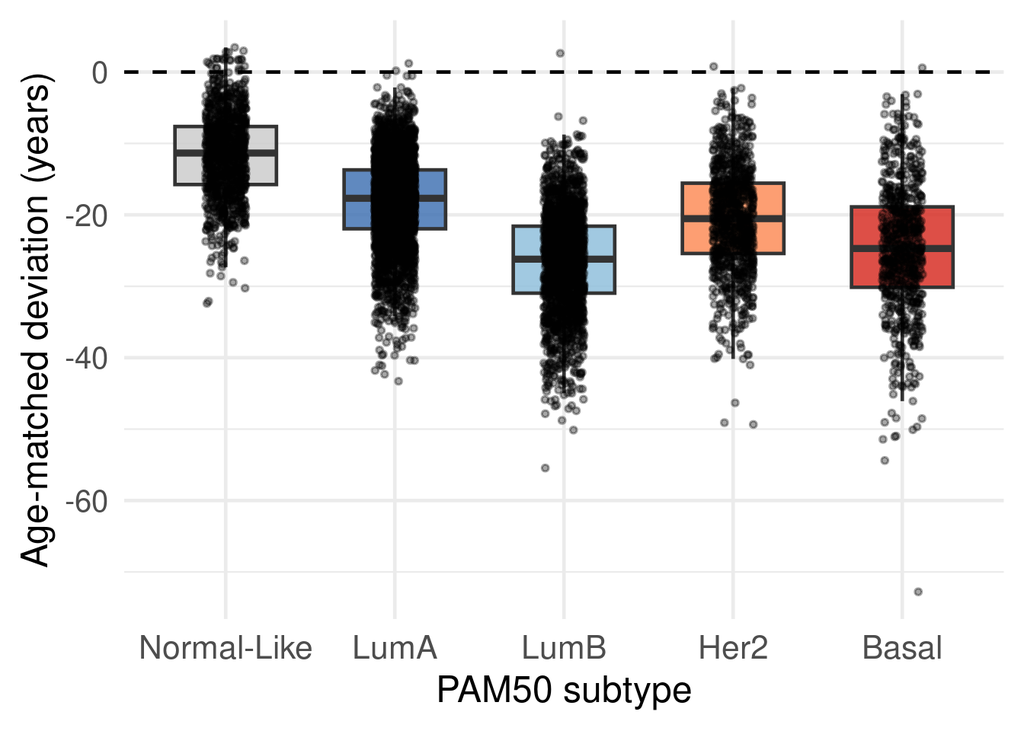

```r
## -------------------------------------------------------------
## Deviation (predicted − expected) by PAM50 subtype
## -------------------------------------------------------------

sid <- rownames(cs_scanb$phi)
delta_scanb <- as.numeric(cs_scanb$deviation)

pam50 <- as.character(SummarizedExperiment::colData(scanb_tumor)[sid, "SSP.PAM50"])
pam50[is.na(pam50) | pam50 == ""] <- "Unclassified"

df <- tibble::tibble(
  sample_id = sid,
  DeltaAge  = delta_scanb,
  PAM50     = pam50
) %>%
  dplyr::filter(is.finite(DeltaAge), !is.na(PAM50)) %>%
  dplyr::mutate(
    PAM50 = dplyr::recode(PAM50, "Normal" = "Normal-Like"),
    PAM50 = factor(PAM50, levels = c("Normal-Like", "LumA", "LumB", "Her2", "Basal", "Unclassified"))
  )

pal_pam50 <- c(
  "Normal-Like" = "#cccccc",
  LumA          = "#4575b4",
  LumB          = "#91bfdb",
  Her2          = "#fc8d59",
  Basal         = "#d73027",
  Unclassified  = "grey70"
)

p_supp3B <- ggplot(df, aes(x = PAM50, y = DeltaAge, fill = PAM50)) +
  geom_boxplot(width = 0.6, outlier.shape = NA, alpha = 0.85) +
  geom_jitter(width = 0.12, alpha = 0.35, size = 1) +
  geom_hline(yintercept = 0, linetype = "dashed") +
  scale_fill_manual(values = pal_pam50, guide = "none") +
  labs(
    x = "PAM50 subtype",
    y = "Age-matched deviation (years)"
  ) +
  theme_minimal(base_size = 18) +
  theme(
    axis.title.x = element_text(size = 18),
    axis.title.y = element_text(size = 18),
    axis.text.x  = element_text(size = 16),
    axis.text.y  = element_text(size = 15),
    plot.margin  = margin(10, 10, 10, 10)
  )

p_supp3B
```

```r
# Optional omnibus test annotation
kw <- kruskal.test(DeltaAge ~ PAM50, data = df)
kw
```

```
##
##  Kruskal-Wallis rank sum test
##
## data:  DeltaAge by PAM50
## Kruskal-Wallis chi-squared = 2580.9, df = 4, p-value < 2.2e-16
```

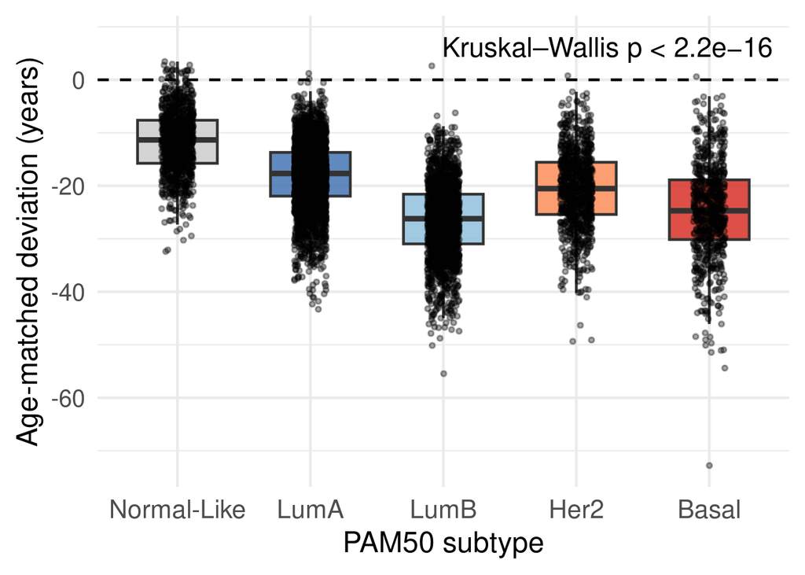

```r
kw_p <- kw$p.value
kw_label <- if (is.finite(kw_p) && kw_p < 2.2e-16) {
  "Kruskal–Wallis p < 2.2e−16"
} else {
  paste0("Kruskal–Wallis p = ", signif(kw_p, 3))
}

ymax <- max(df$DeltaAge, na.rm = TRUE)
ymin <- min(df$DeltaAge, na.rm = TRUE)
ypad <- 0.06 * (ymax - ymin)

p_supp3B_kw <- p_supp3B +
  annotate(
    "text",
    x = Inf, y = ymax + ypad,
    label = kw_label,
    hjust = 1.05, vjust = 1,
    size = 6
  ) +
  coord_cartesian(clip = "off") +
  theme(plot.margin = margin(t = 10, r = 10, b = 10, l = 10))

p_supp3B_kw
```

```r
if (isTRUE(params$save_figures)) {
  out_dir <- FIG_DIR
  dir.create(out_dir, recursive = TRUE, showWarnings = FALSE)

  ggsave(
    filename = file.path(out_dir, "supplementary_scanb_deltaage_by_pam50_kw.pdf"),
    plot   = p_supp3B_kw,
    width  = 210 / 25.4,
    height = 120 / 25.4,
    units  = "in"
  )

  message("Saved: ", file.path(out_dir, "supplementary_scanb_deltaage_by_pam50_kw.pdf"))
} else {
  message("save_figures=FALSE; skipping save: supplementary_scanb_deltaage_by_pam50_kw.pdf")
}
```

## ClockSHAP waterfall for one representative SCAN-B tumor

```r
## -------------------------------------------------------------
## ClockSHAP waterfall (choose a readable tumor)
## -------------------------------------------------------------

pick_pretty_waterfall_sample <- function(cs, top_n = 10,
                                        dev_q = c(0.20, 0.80),
                                        min_bar = 2.5) {
  stopifnot(inherits(cs, "clockshap"))
  phi <- cs$phi
  ids <- rownames(phi)
  if (is.null(ids)) stop("ClockSHAP object has no rownames for phi.", call. = FALSE)

  ok <- is.finite(cs$deviation) & is.finite(cs$expected) & is.finite(cs$predicted)
  phi <- phi[ok, , drop = FALSE]
  dev <- cs$deviation[ok]
  ids <- ids[ok]

  lo <- unname(stats::quantile(dev, dev_q[1], na.rm = TRUE))
  hi <- unname(stats::quantile(dev, dev_q[2], na.rm = TRUE))
  keep <- dev >= lo & dev <= hi

  phi2 <- phi[keep, , drop = FALSE]
  ids2 <- ids[keep]
  if (nrow(phi2) == 0) stop("No samples left after dev_q filtering.", call. = FALSE)

  top_abs <- t(apply(abs(phi2), 1, function(v) sort(v, decreasing = TRUE)[seq_len(top_n)]))
  min_top  <- apply(top_abs, 1, min)
  mean_top <- rowMeans(top_abs)

  cand <- which(min_top >= min_bar)
  if (length(cand) == 0) cand <- seq_len(nrow(phi2))
  ids2[cand[which.max(mean_top[cand])]]
}

sample_id <- pick_pretty_waterfall_sample(
  cs = cs_scanb,
  top_n = 10,
  dev_q = c(0.20, 0.80),
  min_bar = 2.5
)

pt_summary <- tibble::tibble(
  sample_id = sample_id,
  age       = cs_scanb$age[match(sample_id, rownames(cs_scanb$phi))],
  predicted = cs_scanb$predicted[match(sample_id, rownames(cs_scanb$phi))],
  expected  = cs_scanb$expected[match(sample_id, rownames(cs_scanb$phi))],
  deviation = cs_scanb$deviation[match(sample_id, rownames(cs_scanb$phi))]
)
pt_summary
```

```
## # A tibble: 1 × 5
##   sample_id                        age predicted expected deviation
##   <chr>                          <dbl>     <dbl>    <dbl>     <dbl>
## 1 S011834.l.r.n.m.c.lib.g.k2.a.t    45      36.3     50.6     -14.4
```

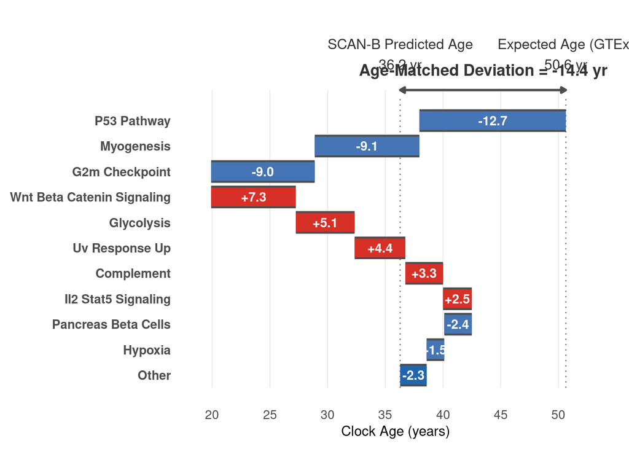

```r
p_supp3C <- ClockSHAP::plot_clockshap_waterfall(
  x = cs_scanb,
  sample = sample_id,
  top_n = 10,
  show_age_labels = TRUE,
  show_delta_label = TRUE,
  show_effect_labels = TRUE,
  x_axis_title = "Clock Age (years)",
  y_axis_title = NULL,
  deviation_label = "Age-Matched Deviation = {value} yr",
  expected_age_label = "Expected Age (GTEx)\n{value} yr",
  predicted_age_label = "SCAN-B Predicted Age\n{value} yr",
  effect_label = "{value}"
)

p_supp3C
```

```r
if (isTRUE(params$save_figures)) {
  out_dir <- FIG_DIR
  dir.create(out_dir, recursive = TRUE, showWarnings = FALSE)

  ggsave(
    filename = file.path(out_dir, "supplementary_scanb_clockshap_waterfall.pdf"),
    plot   = p_supp3C,
    width  = 210 / 25.4,
    height = 120 / 25.4,
    units  = "in"
  )

  message("Saved: ", file.path(out_dir, "supplementary_scanb_clockshap_waterfall.pdf"))
} else {
  message("save_figures=FALSE; skipping save: supplementary_scanb_clockshap_waterfall.pdf")
}
```

## Heatmap of ClockSHAP contributions across SCAN-B tumors

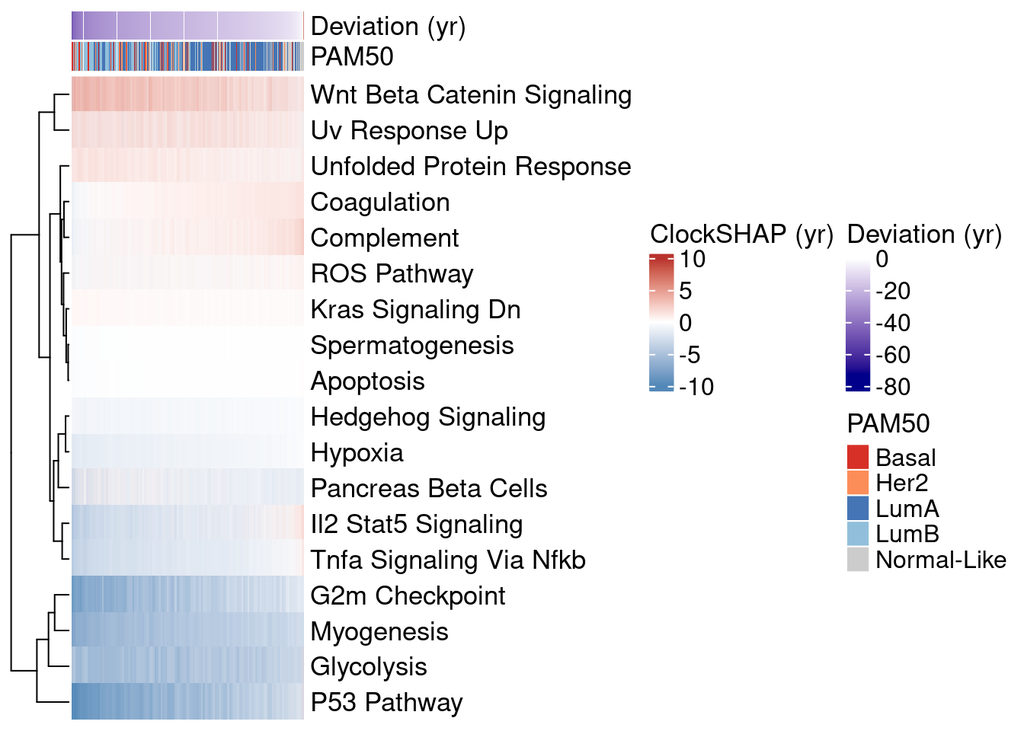

```r
## -------------------------------------------------------------
## ClockSHAP heatmap (SCAN-B), ordered by deviation
##   Rows = pathways (Hallmarks), Columns = tumors
## -------------------------------------------------------------

phi <- cs_scanb$phi
dev <- cs_scanb$deviation
ids <- rownames(phi)
stopifnot(!is.null(ids), length(dev) == nrow(phi))

ok <- is.finite(dev)
phi_ok <- phi[ok, , drop = FALSE]
dev_ok <- dev[ok]
ids_ok <- ids[ok]

ord <- order(dev_ok, decreasing = FALSE)
phi_ord <- phi_ok[ord, , drop = FALSE]
dev_ord <- dev_ok[ord]
ids_ord <- ids_ok[ord]

mat <- t(phi_ord)
colnames(mat) <- ids_ord
mat <- mat[rowSums(abs(mat), na.rm = TRUE) != 0, , drop = FALSE]

rownames(mat)[rownames(mat) == "Reactive Oxygen Species Pathway"] <- "ROS Pathway"

# Column annotations: PAM50 (if available)
pam <- as.character(SummarizedExperiment::colData(scanb_tumor)[ids_ord, "SSP.PAM50"])
pam[is.na(pam) | pam == ""] <- "Unclassified"
pam <- dplyr::recode(pam, "Normal" = "Normal-Like")

pam_cols <- c(
  Basal        = "#d73027",
  Her2         = "#fc8d59",
  LumA         = "#4575b4",
  LumB         = "#91bfdb",
  `Normal-Like`= "#cccccc",
  Unclassified = "grey70"
)

# Optional extra annotation(s) if present
extra_ann <- list()
extra_cols <- list()
cd <- as.data.frame(SummarizedExperiment::colData(scanb_tumor))

if ("TP53" %in% colnames(cd)) {
  tp53 <- as.character(SummarizedExperiment::colData(scanb_tumor)[ids_ord, "TP53"])
  extra_ann$TP53 <- tp53
  extra_cols$TP53 <- c(WT = "grey85", Mut = "black")
}

dev_col_fun <- circlize::colorRamp2(
  c(min(dev_ord, na.rm = TRUE), 0, max(dev_ord, na.rm = TRUE)),
  c("darkblue", "white", "darkred")
)

ann_args <- c(
  list(
    Deviation = dev_ord,
    PAM50     = pam
  ),
  extra_ann,
  list(
    col = c(
      list(
        Deviation = dev_col_fun,
        PAM50     = pam_cols
      ),
      extra_cols
    ),
    annotation_label = c(
      Deviation = "Deviation (yr)",
      PAM50     = "PAM50",
      setNames(names(extra_ann), names(extra_ann))
    ),
    annotation_height = unit(rep(3, 2 + length(extra_ann)), "mm"),
    annotation_name_gp = gpar(fontsize = 13),
    annotation_legend_param = list(
      Deviation = list(
        title_gp  = gpar(fontsize = 13),
        labels_gp = gpar(fontsize = 12)
      ),
      PAM50 = list(
        title_gp  = gpar(fontsize = 13),
        labels_gp = gpar(fontsize = 12)
      )
    )
  )
)

ha <- do.call(ComplexHeatmap::HeatmapAnnotation, ann_args)

phi_lim <- as.numeric(stats::quantile(abs(mat), probs = 0.99, na.rm = TRUE))
phi_lim <- max(phi_lim, 1e-6)

phi_col_fun <- circlize::colorRamp2(
  c(-phi_lim, 0, phi_lim),
  c("steelblue", "white", "firebrick")
)

ht_supp3D <- ComplexHeatmap::Heatmap(
  mat,
  name              = "ClockSHAP (yr)",
  col               = phi_col_fun,
  top_annotation    = ha,
  show_row_names    = TRUE,
  row_names_gp      = gpar(fontsize = 13),
  show_column_names = FALSE,
  cluster_rows      = TRUE,
  cluster_columns   = FALSE,
  heatmap_legend_param = list(
    title_gp  = gpar(fontsize = 13),
    labels_gp = gpar(fontsize = 12)
  )
)

ht_supp3D
```

```r
if (isTRUE(params$save_figures)) {
  out_dir <- FIG_DIR
  dir.create(out_dir, recursive = TRUE, showWarnings = FALSE)

  out_file <- file.path(out_dir, "supplementary_scanb_clockshap_heatmap.pdf")

  grDevices::pdf(out_file, width = 190 / 25.4, height = 160 / 25.4)
  ComplexHeatmap::draw(
    ht_supp3D,
    heatmap_legend_side    = "right",
    annotation_legend_side = "right",
    merge_legends          = TRUE
  )
  grDevices::dev.off()

  message("Saved: ", out_file)
} else {
  message("save_figures=FALSE; skipping save: supplementary_scanb_clockshap_heatmap.pdf")
}
```

## Deviation by PAM50 subtype (TCGA BRCA vs SCAN-B)

This is a side-by-side visualization of the PAM50–deviation structure in **TCGA BRCA (PT)** versus **SCAN-B tumors**.

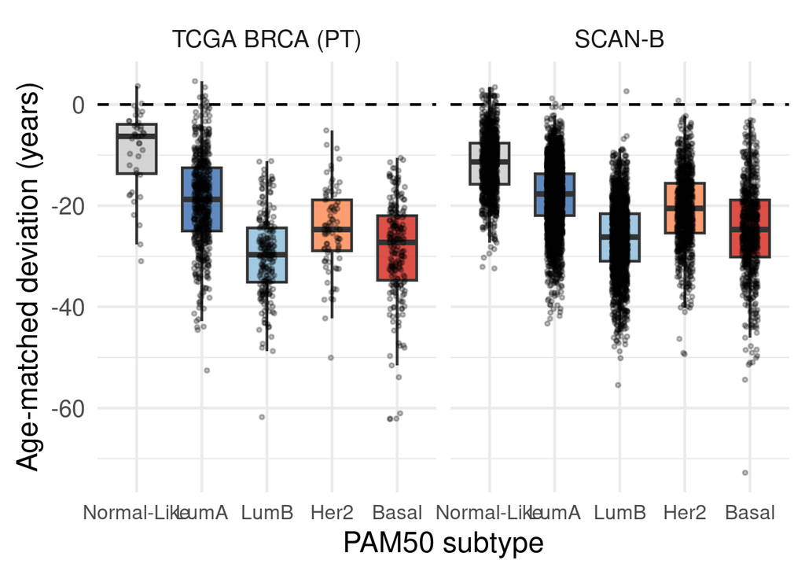

```r
## -------------------------------------------------------------
## Deviation by PAM50 (BRCA vs SCAN-B), side-by-side
## -------------------------------------------------------------

stopifnot(inherits(cs_pt, "clockshap"), inherits(cs_scanb, "clockshap"))

# ---- SCAN-B ----
sid_s <- rownames(cs_scanb$phi)
dev_s <- as.numeric(cs_scanb$deviation)

pam_s <- as.character(SummarizedExperiment::colData(scanb_tumor)[sid_s, "SSP.PAM50"])
pam_s[is.na(pam_s) | pam_s == ""] <- "Unclassified"
pam_s <- dplyr::recode(pam_s, "Normal" = "Normal-Like")

df_scanb_pam <- tibble::tibble(
  cohort    = "SCAN-B",
  sample_id = sid_s,
  PAM50     = pam_s,
  DeltaAge  = dev_s
) %>%
  dplyr::filter(is.finite(DeltaAge), !is.na(PAM50))

# ---- TCGA BRCA (PT) ----
sid_b <- rownames(cs_pt$phi)
dev_b <- as.numeric(cs_pt$deviation)

# Try to find the PAM50 column
pam_candidates <- c(
  "Subtype_Selected",
  "PAM50",
  "PAM50_Subtype",
  "PAM50.Subtype",
  "PAM50_call",
  "pam50"
)
pam_col <- intersect(pam_candidates, colnames(metadata))[1]

if (length(pam_col) == 0 || is.na(pam_col)) {
  stop(
    "Could not find a PAM50 subtype column in `metadata`. Looked for: ",
    paste(pam_candidates, collapse = ", "),
    call. = FALSE
  )
}

pam_b <- as.character(metadata[sid_b, pam_col])
pam_b[is.na(pam_b) | pam_b == ""] <- "Unclassified"
pam_b <- dplyr::recode(pam_b, "Normal" = "Normal-Like")

df_brca_pam <- tibble::tibble(
  cohort    = "TCGA BRCA (PT)",
  sample_id = sid_b,
  PAM50     = pam_b,
  DeltaAge  = dev_b
) %>%
  dplyr::filter(is.finite(DeltaAge), !is.na(PAM50))

# ---- Combine + plot ----
df_both <- dplyr::bind_rows(df_brca_pam, df_scanb_pam) %>%
  dplyr::mutate(
    cohort = factor(cohort, levels = c("TCGA BRCA (PT)", "SCAN-B")),
    PAM50  = factor(PAM50, levels = c("Normal-Like", "LumA", "LumB", "Her2", "Basal", "Unclassified"))
  )

pal_pam50 <- c(
  "Normal-Like" = "#cccccc",
  LumA          = "#4575b4",
  LumB          = "#91bfdb",
  Her2          = "#fc8d59",
  Basal         = "#d73027",
  Unclassified  = "grey70"
)

p_supp3B2 <- ggplot2::ggplot(df_both, ggplot2::aes(x = PAM50, y = DeltaAge, fill = PAM50)) +
  ggplot2::geom_boxplot(width = 0.6, outlier.shape = NA, alpha = 0.85) +
  ggplot2::geom_jitter(width = 0.12, alpha = 0.25, size = 0.8) +
  ggplot2::geom_hline(yintercept = 0, linetype = "dashed") +
  ggplot2::facet_grid(. ~ cohort) +
  ggplot2::scale_fill_manual(values = pal_pam50, guide = "none") +
  ggplot2::labs(
    x = "PAM50 subtype",
    y = "Age-matched deviation (years)"
  ) +
  ggplot2::theme_minimal(base_size = 18) +
  ggplot2::theme(
    axis.title.x = ggplot2::element_text(size = 18),
    axis.title.y = ggplot2::element_text(size = 18),
    axis.text.x  = ggplot2::element_text(size = 12.5),
    axis.text.y  = ggplot2::element_text(size = 15),
    strip.text.x = ggplot2::element_text(size = 15),
    plot.margin  = ggplot2::margin(10, 10, 10, 10)
  )

p_supp3B2
```

```r
if (isTRUE(params$save_figures)) {
  out_dir <- FIG_DIR
  dir.create(out_dir, recursive = TRUE, showWarnings = FALSE)

  ggsave(
    filename = file.path(out_dir, "supplementary_brca_vs_scanb_deltaage_by_pam50.pdf"),
    plot   = p_supp3B2,
    width  = 240 / 25.4,
    height = 140 / 25.4,
    units  = "in"
  )

  message("Saved: ", file.path(out_dir, "supplementary_brca_vs_scanb_deltaage_by_pam50.pdf"))
} else {
  message("save_figures=FALSE; skipping save: supplementary_brca_vs_scanb_deltaage_by_pam50.pdf")
}
```

## Program-resolved coupling check (SCAN-B; coupling analysis not in the manuscript)

This reproduces the **program-resolved coupling** visualization (contribution = *w × β_tumor*), using: - **GTEx** as the reference aging direction in feature space (via β_z in GTEx), and - **SCAN-B tumors** as the validation tumor cohort.

```r
## -------------------------------------------------------------
## Coupling plot (SCAN-B vs GTEx)
##   Contribution per pathway: w_k * beta_{SCANB,k} in Z-space
##   Bar color: GTEx aging direction in Z-space
## -------------------------------------------------------------

# --- Helper functions (minimal subset from coupling template) ---
fit_slope <- function(y, age) {
  ok <- complete.cases(y, age)
  y <- as.numeric(y[ok])
  age <- as.numeric(age[ok])
  if (length(y) < 3) return(tibble::tibble(n = length(y), intercept = NA_real_, slope = NA_real_))
  fit <- stats::lm(y ~ age)
  tibble::tibble(n = length(y), intercept = unname(stats::coef(fit)[1]), slope = unname(stats::coef(fit)[2]))
}

standardize_like_clock <- function(X, mu, sigma) {
  stopifnot(all(colnames(X) %in% names(mu)), all(colnames(X) %in% names(sigma)))
  mu2 <- mu[colnames(X)]
  sd2 <- sigma[colnames(X)]
  if (any(!is.finite(sd2)) || any(sd2 == 0)) stop("Non-finite or zero sigma in clock; cannot standardize.")
  Z <- sweep(X, 2, mu2, "-")
  Z <- sweep(Z, 2, sd2, "/")
  Z
}

col_slopes_vs_age <- function(Z, age) {
  ok <- is.finite(age) & (rowSums(!is.finite(Z)) == 0)
  Z <- Z[ok, , drop = FALSE]
  age <- as.numeric(age[ok])
  if (nrow(Z) < 3) return(setNames(rep(NA_real_, ncol(Z)), colnames(Z)))

  age_c <- age - mean(age)
  den <- sum(age_c^2)
  if (!is.finite(den) || den == 0) return(setNames(rep(NA_real_, ncol(Z)), colnames(Z)))

  Z_c <- sweep(Z, 2, colMeans(Z), "-")
  slopes <- colSums(Z_c * age_c) / den
  setNames(as.numeric(slopes), colnames(Z))
}

# --- Clock parameters in standardized space (Step 02 contract) ---
cs <- clock_results$clock_cs
feat <- clock_results$feature_names

w   <- cs$beta;  if (is.null(names(w)))   names(w)   <- feat
mu  <- cs$mu;    if (is.null(names(mu)))  names(mu)  <- feat
sig <- cs$sigma; if (is.null(names(sig))) names(sig) <- feat

# --- Build GTEx feature matrix (samples × pathways) aligned to Step-02 ages ---
pred_gtex_raw <- clock_results$pred$GTEx
age_gtex_raw  <- clock_results$age$GTEx[names(pred_gtex_raw)]

ok_g <- complete.cases(age_gtex_raw) & is.finite(age_gtex_raw)
age_gtex_raw <- age_gtex_raw[ok_g]

ids_gtex <- intersect(names(age_gtex_raw), colnames(scores_gtex))
X_gtex <- t(scores_gtex[feat, ids_gtex, drop = FALSE])
age_g  <- as.numeric(age_gtex_raw[ids_gtex])

# --- Use SCAN-B tumor features already prepared for the clock ---
# (X_scanb_cs is samples × pathways, age_scanb_cs is numeric)
stopifnot(exists("X_scanb_cs"), exists("age_scanb_cs"))
X_s <- X_scanb_cs
a_s <- as.numeric(age_scanb_cs)

# --- Z-space standardization + slopes ---
Z_g <- standardize_like_clock(X_gtex, mu = mu, sigma = sig)
Z_s <- standardize_like_clock(X_s,    mu = mu, sigma = sig)

beta_z_gtex  <- col_slopes_vs_age(Z_g, age_g)
beta_z_scanb <- col_slopes_vs_age(Z_s, a_s)

contrib_tbl <- tibble::tibble(
  pathway     = feat,
  weight_w    = as.numeric(w[feat]),
  beta_z_scanb = as.numeric(beta_z_scanb[feat]),
  beta_z_gtex  = as.numeric(beta_z_gtex[feat])
) %>%
  dplyr::mutate(
    contrib = weight_w * beta_z_scanb,
    contrib = ifelse(abs(weight_w) < 1e-12, 0, contrib)
  )

# --- Identity check: sum_k w_k * beta_k == slope(predicted ~ age) in raw space ---
pred_s_raw <- as.numeric(cs$alpha + Z_s %*% as.numeric(w[feat]))
gamma_scanb_raw <- fit_slope(pred_s_raw, a_s)$slope
gamma_from_decomp <- sum(contrib_tbl$contrib, na.rm = TRUE)

tibble::tibble(
  gamma_scanb_raw = gamma_scanb_raw,
  gamma_from_decomp = gamma_from_decomp,
  abs_diff = abs(gamma_scanb_raw - gamma_from_decomp)
)
```

```
## # A tibble: 1 × 3
##   gamma_scanb_raw gamma_from_decomp abs_diff
##             <dbl>             <dbl>    <dbl>
## 1         0.00922           0.00922 7.98e-17
```

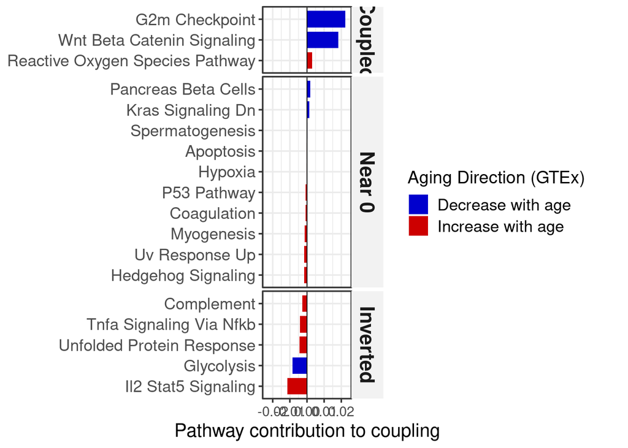

```r
# --- Coupling plot ---
top_n <- 25
gtex_beta_eps <- 0.0
neutral_band <- 0.002
eps_w <- 1e-12

plot_df <- contrib_tbl %>%
  dplyr::filter(is.finite(weight_w), abs(weight_w) >= eps_w, is.finite(contrib)) %>%
  dplyr::mutate(
    abs_contrib = abs(contrib),
    gtex_age_dir = dplyr::case_when(
      beta_z_gtex >  gtex_beta_eps ~ "Increase with age",
      beta_z_gtex < -gtex_beta_eps ~ "Decrease with age",
      TRUE ~ "Flat / ~0"
    ),
    coupling_section = dplyr::case_when(
      contrib >=  neutral_band ~ "Coupled",
      contrib <= -neutral_band ~ "Inverted",
      TRUE ~ "Near 0"
    )
  ) %>%
  dplyr::arrange(dplyr::desc(abs_contrib)) %>%
  dplyr::slice_head(n = top_n) %>%
  dplyr::mutate(
    coupling_section = factor(coupling_section, levels = c("Coupled", "Near 0", "Inverted"))
  ) %>%
  dplyr::arrange(contrib) %>%
  dplyr::mutate(pathway = factor(pathway, levels = pathway))

x_lim <- max(abs(plot_df$contrib), na.rm = TRUE)
x_lim <- if (is.finite(x_lim)) x_lim * 1.05 else 1

p_supp3H_coupling <- ggplot2::ggplot(plot_df, ggplot2::aes(x = contrib, y = pathway, fill = gtex_age_dir)) +
  ggplot2::geom_col(width = 0.8) +
  ggplot2::geom_vline(xintercept = 0, linewidth = 0.3) +
  ggplot2::facet_grid(
    coupling_section ~ .,
    scales = "free_y",
    space  = "free_y",
    drop   = TRUE
  ) +
  ggplot2::scale_fill_manual(
    values = c(
      "Increase with age" = "red3",
      "Decrease with age" = "blue3",
      "Flat / ~0"                = "grey70"
    )
  ) +
  ggplot2::coord_cartesian(xlim = c(-x_lim, x_lim), clip = "off") +
  ggplot2::labs(
    x = "Pathway contribution to coupling",
    y = NULL,
    fill = "Aging Direction (GTEx)"
  ) +
  ggplot2::theme_bw(base_size = 13) +
  ggplot2::theme(
    legend.position = "right",
    legend.title = ggplot2::element_text(size = 14),
    legend.text  = ggplot2::element_text(size = 13),
    axis.title.x = ggplot2::element_text(size = 15),
    axis.text.x  = ggplot2::element_text(size = 11),
    axis.text.y  = ggplot2::element_text(size = 13),
    strip.background = ggplot2::element_rect(fill = "grey95", color = NA),
    strip.text.y.right = ggplot2::element_text(angle = -90, size = 16, face = "bold"),
    strip.text.y.left  = ggplot2::element_blank(),
    strip.placement = "outside",
    panel.spacing.y = grid::unit(3, "pt"),
    plot.margin = ggplot2::margin(5.5, 28, 5.5, 5.5, unit = "pt")
  )

p_supp3H_coupling
```

```r
if (isTRUE(params$save_figures)) {
  out_dir <- FIG_DIR
  dir.create(out_dir, recursive = TRUE, showWarnings = FALSE)

  ggsave(
    filename = file.path(out_dir, "supplementary_scanb_coupling.pdf"),
    plot   = p_supp3H_coupling,
    width  = 210 / 25.4,
    height = 180 / 25.4,
    units  = "in"
  )

  message("Saved: ", file.path(out_dir, "supplementary_scanb_coupling.pdf"))
} else {
  message("save_figures=FALSE; skipping save: supplementary_scanb_coupling.pdf")
}
```

## Survival (SCAN-B): Cox per +1 year tumor-intra RAA

This follows the survival template’s logic (Cox models of tumor-intra residuals), adapted to SCAN-B columns in `colData(scanb_tumor)`.

**Key choice:** for “tumor-intra RAA” in SCAN-B, we use residuals from `lm(predicted ~ age)` **within SCAN-B tumors**.

```r
# SCAN-B tumor-intra residuals: ŷ = a + b*Age within SCAN-B
df_intra <- scanb_pred_df %>%
  dplyr::filter(is.finite(age_years), is.finite(predicted))

fit_scanb_intra <- lm(predicted ~ age_years, data = df_intra)
aS <- coef(fit_scanb_intra)[1]
bS <- coef(fit_scanb_intra)[2]

df_intra <- df_intra %>%
  dplyr::mutate(
    RAA_intra = predicted - (aS + bS * age_years)
  )

c(aS = aS, bS = bS)
```

```
## aS.(Intercept)   bS.age_years
##   33.394869567    0.009217475
```

```r
run_survival_scanb <- function(time_col, event_col, title_text,
                               adjust_pam50 = TRUE,
                               min_events = 10) {

  ids <- df_intra$sample_id
  cd <- SummarizedExperiment::colData(scanb_tumor)

  stopifnot(time_col %in% colnames(cd), event_col %in% colnames(cd))

  df <- tibble::tibble(
    sample_id = ids,
    RAA_T     = df_intra$RAA_intra,
    age_years = df_intra$age_years,
    time      = as.numeric(cd[ids, time_col]),
    event     = as.numeric(cd[ids, event_col]),
    PAM50     = as.character(cd[ids, "SSP.PAM50"])
  ) %>%
    dplyr::filter(is.finite(RAA_T), is.finite(age_years), is.finite(time), !is.na(event)) %>%
    dplyr::mutate(
      event = as.integer(event > 0),
      PAM50 = dplyr::case_when(
        is.na(PAM50) ~ "Unclassified",
        PAM50 == ""  ~ "Unclassified",
        TRUE ~ PAM50
      ),
      PAM50 = factor(PAM50, levels = c("Normal","LumA","LumB","Her2","Basal","Unclassified"))
    )

  if (sum(df$event) < min_events) {
    warning("Not enough events for ", title_text, ": ", sum(df$event), " < ", min_events)
    return(NULL)
  }

  # Global model(s)
  fit_basic <- coxph(Surv(time, event) ~ RAA_T + age_years, data = df)
  fits <- list(basic = fit_basic)

  if (isTRUE(adjust_pam50)) {
    fit_pam50 <- coxph(Surv(time, event) ~ RAA_T + age_years + PAM50, data = df)
    fits$pam50 <- fit_pam50
  }

  # Per-subtype models (within PAM50)
  tbl_sub <- purrr::map_df(levels(df$PAM50), function(s) {
    d <- dplyr::filter(df, PAM50 == s)
    if (nrow(d) < 15 || length(unique(d$event)) < 2) return(NULL)
    f <- survival::coxph(survival::Surv(time, event) ~ RAA_T + age_years, data = d)
    broom::tidy(f) %>%
      dplyr::filter(term == "RAA_T") %>%
      dplyr::mutate(model = paste("Subtype:", s), n = nrow(d), events = sum(d$event))
  })

  # Assemble forest-table
  tbl <- dplyr::bind_rows(
    broom::tidy(fit_basic) %>%
      dplyr::filter(term == "RAA_T") %>%
      dplyr::mutate(model = "All tumors (RAA + Age)", n = nrow(df), events = sum(df$event)),
    if (isTRUE(adjust_pam50)) broom::tidy(fit_pam50) %>%
      dplyr::filter(term == "RAA_T") %>%
      dplyr::mutate(model = "All tumors + PAM50", n = nrow(df), events = sum(df$event)),
    tbl_sub
  ) %>%
    dplyr::mutate(
      HR    = exp(estimate),
      lower = exp(estimate - 1.96 * std.error),
      upper = exp(estimate + 1.96 * std.error),
      sig   = ifelse(p.value < .05, "p < 0.05", "p ≥ 0.05"),
      direction = ifelse(HR < 1, "Lower risk (HR < 1)", "Higher risk (HR > 1)"),
      label_y = paste0(model, "\n(n=", n, ", events=", events, ")")
    ) %>%
    dplyr::mutate(label_y = factor(label_y, levels = rev(label_y)))

  p <- ggplot(tbl, aes(HR, label_y)) +
    geom_errorbarh(aes(xmin = lower, xmax = upper, colour = direction), height = .20) +
    geom_point(aes(colour = direction, shape = sig), size = 3) +
    geom_vline(xintercept = 1, linetype = "dashed") +
    scale_x_log10(breaks = pretty_breaks(n = 6), labels = label_number(accuracy = 0.01)) +
    scale_colour_manual(
      name = "Direction",
      values = c("Lower risk (HR < 1)" = "#4575b4", "Higher risk (HR > 1)" = "#d73027")
    ) +
    scale_shape_manual(name = "Significance", values = c("p < 0.05" = 19, "p ≥ 0.05" = 1)) +
    labs(
      x = "Hazard ratio (log scale)",
      y = NULL
    ) +
    theme_minimal(base_size = 12) +
    theme(panel.grid.major.y = element_blank(), legend.box = "vertical")

  list(data = df, fits = fits, table = tbl, plot = p)
}
```

### Overall survival (OS)

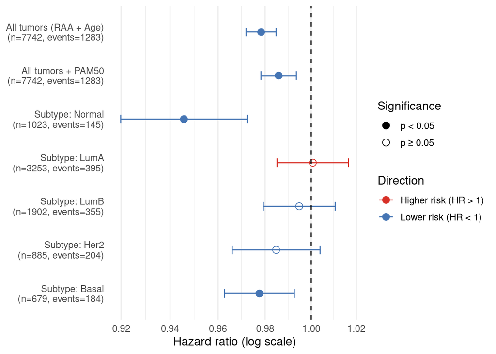

```r
os_out <- run_survival_scanb("OS_days", "OS_event", "Overall Survival (OS)")
os_out$plot
```

```r
if (isTRUE(params$save_figures)) {
  out_dir <- FIG_DIR
  dir.create(out_dir, recursive = TRUE, showWarnings = FALSE)

  ggsave(
    filename = file.path(out_dir, "supplementary_scanb_os_forest.pdf"),
    plot   = os_out$plot,
    width  = 180 / 25.4,
    height = 120 / 25.4,
    units  = "in"
  )

  message("Saved: ", file.path(out_dir, "supplementary_scanb_os_forest.pdf"))
} else {
  message("save_figures=FALSE; skipping save: supplementary_scanb_os_forest.pdf")
}
```

### Recurrence-free interval (RFi)

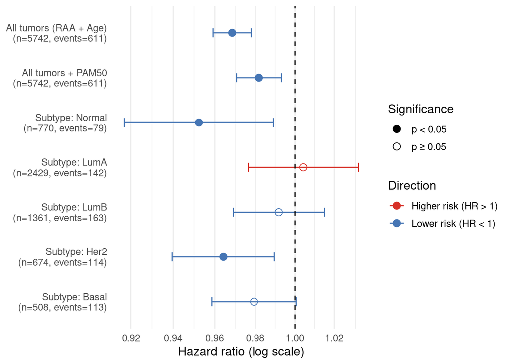

```r
rfi_out <- run_survival_scanb("RFi_days", "RFi_event", "Recurrence-Free Interval (RFi)")
rfi_out$plot
```

```r
if (isTRUE(params$save_figures)) {
  out_dir <- FIG_DIR
  dir.create(out_dir, recursive = TRUE, showWarnings = FALSE)

  ggsave(
    filename = file.path(out_dir, "supplementary_scanb_rfi_forest.pdf"),
    plot   = rfi_out$plot,
    width  = 180 / 25.4,
    height = 120 / 25.4,
    units  = "in"
  )

  message("Saved: ", file.path(out_dir, "supplementary_scanb_rfi_forest.pdf"))
} else {
  message("save_figures=FALSE; skipping save: supplementary_scanb_rfi_forest.pdf")
}
```

```r
scanb_save_dir <- "/restricted/projectnb/agedisease/projects/pancancer_aging_pbock/manuscript_analyses/results/derived/GTEx/BRCA__BREAST"
dir.create(scanb_save_dir, recursive = TRUE, showWarnings = FALSE)

if (isTRUE(params$save_inputs) && !is.null(rfi_out)) {
  saveRDS(
    list(
      endpoint = "RFi",
      table = rfi_out$table
    ),
    file = file.path(
      scanb_save_dir,
      paste0("scanb_rfi_survival_results-", params$feature_set, ".rds")
    )
  )
}
```

### Distant recurrence-free interval (DRFi)

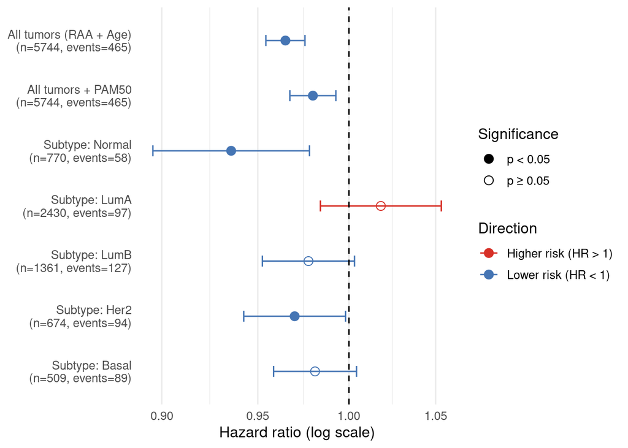

```r
drfi_out <- run_survival_scanb("DRFi_days", "DRFi_event", "Distant Recurrence-Free Interval (DRFi)")
drfi_out$plot
```

```r
if (isTRUE(params$save_figures)) {
  out_dir <- FIG_DIR
  dir.create(out_dir, recursive = TRUE, showWarnings = FALSE)

  ggsave(
    filename = file.path(out_dir, "supplementary_scanb_drfi_forest.pdf"),
    plot   = drfi_out$plot,
    width  = 180 / 25.4,
    height = 120 / 25.4,
    units  = "in"
  )

  message("Saved: ", file.path(out_dir, "supplementary_scanb_drfi_forest.pdf"))
} else {
  message("save_figures=FALSE; skipping save: supplementary_scanb_drfi_forest.pdf")
}
```

### Survival summary across endpoints (combined)

This combines **OS**, **RFi**, and **DRFi** into a single forest-style plot with: - **Rows:** global models (all tumors; PAM50-controlled) plus **within-PAM50** subtype models - **Three point shapes:** one per endpoint (with 95% CI)

```r
os_out2   <- run_survival_scanb("OS_days",   "OS_event",   "Overall Survival (OS)")
rfi_out2  <- run_survival_scanb("RFi_days",  "RFi_event",  "Recurrence-Free Interval (RFi)")
drfi_out2 <- run_survival_scanb("DRFi_days", "DRFi_event", "Distant Recurrence-Free Interval (DRFi)")

outs <- list(OS = os_out2, RFi = rfi_out2, DRFi = drfi_out2)
outs <- outs[!vapply(outs, is.null, logical(1))]

if (length(outs) == 0) {
  stop("No survival endpoints returned results (all NULL). Check SCAN-B time/event columns and event counts.", call. = FALSE)
}

tbl_all <- dplyr::bind_rows(lapply(names(outs), function(ep) {
  outs[[ep]]$table %>%
    dplyr::mutate(endpoint = ep)
}))

tbl_all <- tbl_all %>%
  dplyr::mutate(
    endpoint = factor(endpoint, levels = c("OS", "RFi", "DRFi")),
    model_row = dplyr::case_when(
      model == "All tumors (RAA + Age)" ~ "All tumors",
      model == "All tumors + PAM50"     ~ "PAM50 controlled",
      TRUE ~ model
    )
  )

# Order: global rows first, then PAM50 subtypes (if present)
pam_levels <- NULL
if (length(outs) > 0 && !is.null(outs[[1]]$data) && "PAM50" %in% colnames(outs[[1]]$data)) {
  pam_levels <- levels(outs[[1]]$data$PAM50)
}
sub_lvls <- tbl_all$model_row[grepl("^Subtype:", tbl_all$model_row)] |> unique()
if (!is.null(pam_levels)) {
  sub_lvls <- paste("Subtype:", pam_levels)
  sub_lvls <- sub_lvls[sub_lvls %in% tbl_all$model_row]
}

tbl_all <- tbl_all %>%
  dplyr::mutate(
    model_row = factor(model_row, levels = c("All tumors", "PAM50 controlled", sub_lvls))
  )

# Print a compact results table
tbl_all_print <- tbl_all %>%
  dplyr::select(endpoint, model = model_row, n, events, HR, lower, upper, p.value) %>%
  dplyr::arrange(endpoint, model)

tbl_all_print
```

```
## # A tibble: 21 × 8
##    endpoint model                n events    HR lower upper  p.value
##    <fct>    <fct>            <int>  <int> <dbl> <dbl> <dbl>    <dbl>
##  1 OS       All tumors        7742   1283 0.978 0.972 0.985 6.38e-11
##  2 OS       PAM50 controlled  7742   1283 0.986 0.978 0.994 3.16e- 4
##  3 OS       Subtype: Normal   1023    145 0.946 0.920 0.972 8.01e- 5
##  4 OS       Subtype: LumA     3253    395 1.00  0.985 1.02  9.28e- 1
##  5 OS       Subtype: LumB     1902    355 0.995 0.979 1.01  5.16e- 1
##  6 OS       Subtype: Her2      885    204 0.985 0.966 1.00  1.18e- 1
##  7 OS       Subtype: Basal     679    184 0.978 0.963 0.993 3.60e- 3
##  8 RFi      All tumors        5742    611 0.968 0.959 0.978 9.80e-11
##  9 RFi      PAM50 controlled  5742    611 0.982 0.971 0.993 1.71e- 3
## 10 RFi      Subtype: Normal    770     79 0.952 0.917 0.989 1.16e- 2
## # ℹ 11 more rows
```

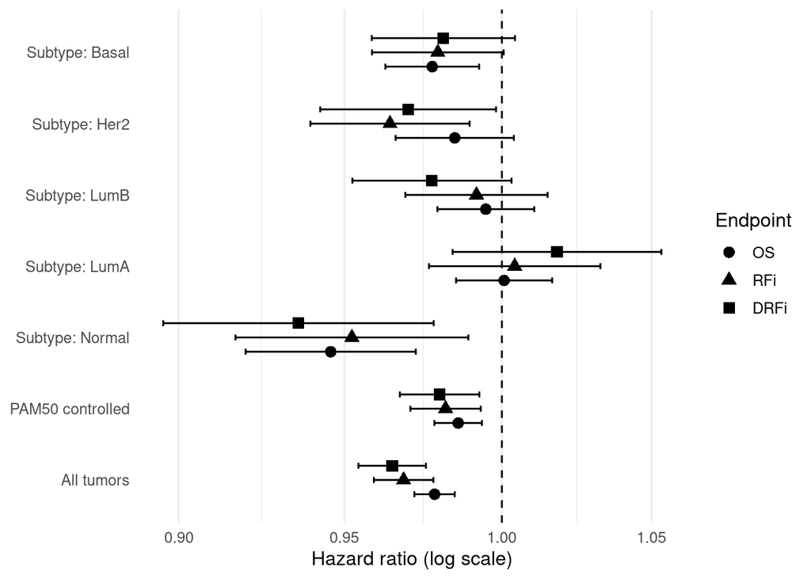

```r
dodge <- ggplot2::position_dodge(width = 0.6)

p_supp3I_surv <- ggplot2::ggplot(
  tbl_all,
  ggplot2::aes(x = HR, y = model_row, shape = endpoint, group = endpoint)
) +
  ggplot2::geom_errorbarh(
    ggplot2::aes(xmin = lower, xmax = upper),
    position = dodge,
    height = 0.25
  ) +
  ggplot2::geom_point(position = dodge, size = 3) +
  ggplot2::geom_vline(xintercept = 1, linetype = "dashed") +
  ggplot2::scale_x_log10(
    breaks = scales::pretty_breaks(n = 6),
    labels = scales::label_number(accuracy = 0.01)
  ) +
  ggplot2::scale_shape_manual(
    name = "Endpoint",
    values = c(OS = 16, RFi = 17, DRFi = 15)
  ) +
  ggplot2::labs(
    x = "Hazard ratio (log scale)",
    y = NULL
  ) +
  ggplot2::theme_minimal(base_size = 12) +
  ggplot2::theme(
    panel.grid.major.y = ggplot2::element_blank(),
    legend.position = "right"
  )

p_supp3I_surv
```

```r
if (isTRUE(params$save_figures)) {
  out_dir <- FIG_DIR
  dir.create(out_dir, recursive = TRUE, showWarnings = FALSE)

  ggsave(
    filename = file.path(out_dir, "supplementary_scanb_survival_combined_endpoints.pdf"),
    plot   = p_supp3I_surv,
    width  = 180 / 25.4,
    height = 110 / 25.4,
    units  = "in"
  )

  message("Saved: ", file.path(out_dir, "supplementary_scanb_survival_combined_endpoints.pdf"))
} else {
  message("save_figures=FALSE; skipping save: supplementary_scanb_survival_combined_endpoints.pdf")
}
```

## Save SCAN-B inputs for downstream figure scripts

Pulls the ssGSEA matrix and a tidied `coldata` (age, PAM50, all three survival endpoints) and writes them to a single `.rds` so the deviation/survival figure scripts don’t need to re-run SCAN-B preprocessing.

```r
scanb_cd <- as.data.frame(SummarizedExperiment::colData(scanb_tumor))

# Helper: pull a column if present, else fill NA. Lets the save succeed even
# if a particular endpoint is missing in some SCAN-B builds.
pull_col <- function(df, col, type = c("numeric", "character")) {
  type <- match.arg(type)
  if (col %in% colnames(df)) {
    if (type == "numeric") as.numeric(df[[col]]) else as.character(df[[col]])
  } else {
    if (type == "numeric") rep(NA_real_, nrow(df)) else rep(NA_character_, nrow(df))
  }
}

scanb_inputs <- list(
  ssgsea_scores = scanb_scores_pxs,
  coldata = data.frame(
    sample_id   = rownames(scanb_cd),
    age_years   = pull_col(scanb_cd, "age_years"),
    SSP.PAM50   = pull_col(scanb_cd, "SSP.PAM50", "character"),

    # All three survival endpoints
    OS_days     = pull_col(scanb_cd, "OS_days"),
    OS_event    = pull_col(scanb_cd, "OS_event"),
    RFi_days    = pull_col(scanb_cd, "RFi_days"),
    RFi_event   = pull_col(scanb_cd, "RFi_event"),
    DRFi_days   = pull_col(scanb_cd, "DRFi_days"),
    DRFi_event  = pull_col(scanb_cd, "DRFi_event"),

    # NOTE: TP53 is attached downstream in the deviation figure script
    # (using the Brueffer 2020 mutation TSV). Not saved here.

    row.names   = rownames(scanb_cd),
    stringsAsFactors = FALSE
  )
)

# Sanity check: report event counts per endpoint so you can confirm OS landed
endpoint_event_counts <- sapply(
  c("OS_event", "RFi_event", "DRFi_event"),
  function(col) sum(scanb_inputs$coldata[[col]] > 0, na.rm = TRUE)
)
message(
  "SCAN-B endpoint event counts saved: ",
  paste(names(endpoint_event_counts), endpoint_event_counts, sep = "=", collapse = " | ")
)

saveRDS(
  scanb_inputs,
  "/restricted/projectnb/agedisease/projects/pancancer_aging_pbock/manuscript_analyses/results/derived/GTEx/BRCA__BREAST/scanb_pathway_inputs.rds"
)
```